```python
from IPython.core.display import HTML

style = """
<style>
body {
    font-family: 'STIXGeneral', sans-serif;
}
</style>
"""

HTML(style)
```

# Skriftlig innlevering 1, Oppgave 1-8

## Oppgave 1 *

For å bestemme matematiske uttrykk for sannsynligheter av hendelser er det ofte enklest å visualisere sannsynligheten for hendelsen som et areal i et venndiagram. Start med å overbevise deg selv om at $P(A^\prime)=1-P(A)$ og at $P(A\cup B)= P(A) + P(B) -P(A\cap B)$ for hendelser $A$ og $B$ i et utfallsrom $S$ ved hjelp av venndiagram. Vis deretter at følgende sannsynligheter er like

\begin{align*} P((A\cup B)^\prime) &= P(A^\prime \cap B^\prime),\\ P((A\cap B)^\prime) &= P(A^\prime \cup B^\prime).\\ \end{align*}

Tips: tegn og skravér i ett venndiagram for hver side av likhetstegnet.

Tekstoppgaver kommer nederst i PDFen

$$ Besvarelse $$

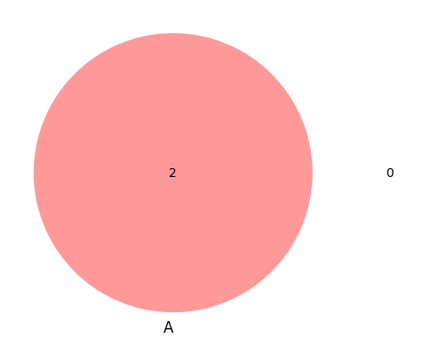

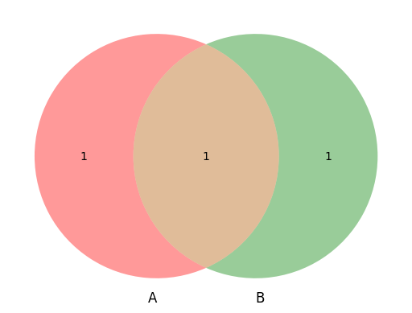

```python
import matplotlib.pyplot as plt
from matplotlib_venn import venn2

set1 = set(['A','C'])
set2 = set(['B','C'])


venn2([set1, set()], ('A', ''))
plt.show()
venn2([set1, set2], ('A', 'B'))
plt.show()
```

Visst $S=1$, så blir $P(A')=P(S)-P(A)=1-P(A)$. Og vi ser av venn diagrammet at $A\cap A'=Ø$

For å bevise dei to identitetane, bruker vi egenskapene til komplementære sett og uniona og snitt av sett. dei identitetane er kjent som De Morgans lover:

1. **Bevis for $ P((A \cup B)^\prime) = P(A^\prime \cap B^\prime) $**
   - $ (A \cup B)^\prime $ er komplementa til unionen av setta $ A $ og $ B $. Som betyr at det inneheldei alle elementer som ikkje er i $ A $ eller $ B $.
   - $ A^\prime \cap B^\prime $ er snittet av komplementa til $ A $ og $ B $. ditta betyr at det innehelde alle elementer som ikkje er i $ A $ og ikkje i $ B $.
   - Sia begge dissa settene innehelde nøyaktig dei samme elementene (dei som ikkje er i $ A $ eller $ B $), er dei like, og derfor er deira sannsynligheta like.
2. **Bevis for $ P((A \cap B)^\prime) = P(A^\prime \cup B^\prime) $**
   - $ (A \cap B)^\prime $ er komplementa til snittet av setta $ A $ og $ B $. ditta betyr at det innehelde alle elementer som ikkje er i både $ A $ og $ B $.
   - $ A^\prime \cup B^\prime $ er unionen av komplementene til $ A $ og $ B $. ditta betyr at det innehelde alle elementer som ikkje er i $ A $, eller ikkje i $ B $, eller begge deler.
   - Igjen, siden begge dissa settene innehelde nøyaktig de samme elementene (de som ikkje er i både $ A $ og $ B $), er dei like, og derfor er deiras sannsynligheta like.

## Oppgave 2 *

Anta at vi har en urne med $34$ kuler. Av disse $34$ kulene er sju kuler røde og resten blå. Anta at vi tilfeldig trekker ut sju av de $34$ kulene, uten tilbakelegging.

- Hva er sannsynligheten for at alle de sju kulene vi trekker ut er røde?
- Hva er sannsynligheten for at nøyaktig fire av de sju kulene vi trekker ut er røde?

Anta så at vi etter å ha trukket ut sju kuler fra urna, trekker ut enda ei kule tilfeldig blant de $27$ kulene som er igjen i urna. Denne siste kula kaller vi ekstrakule.

- Hva er sannsynligheten for at nøyaktig seks av de sju kulene vi først trakk ut er røde og at også ekstrakula er rød?

$$ Besvarelse $$

a) vi har ein mulighet for å trekke 7 raude kuler på 7 trekk, det er med å trekke 7 raude og 0 blå $$\Rightarrow P = \frac{\binom{7}{7}\binom{27}{0}}{\binom{34}{7}} = \frac{7!\times27!}{34!} \approx 1,859\times10^{-7}$$

b) vi kan trekke nøyaktig 4 av 7 raude kula på 1 måte, 4 raude og 3 blå $$\Rightarrow P = \frac{\binom{7}{4}\binom{27}{3}}{\binom{34}{7}} = \frac{7!\times7!\times27!\times27!}{34!\times4!\times3!\times3!\times24!} \approx 0,0190$$

c)vi kan trekke først 6 av 7 raude og så 1 av 1 raude kuler etterpå på ein måte. $$\Rightarrow P = \frac{\binom{7}{6}\binom{27}{1}}{\binom{34}{7}} \times \frac{\binom{1}{1}\binom{26}{0}}{\binom{27}{1}} = \frac{7!\times7!\times27!}{6!\times34!} \approx 1,301\times10^{-6}$$

## Oppgave 3 *

I et lotteri er det $300$ lodd. Tre av loddene gir en gevinst av type $A$ og tre andre lodd gir en gevinst av type $B$. De ørige 294 loddene gir ingen gevinst. Ola kjøper fem lodd som han trekker tilfeldig blant de $300$ loddene.

- Hva er sannsynligheten for at Ola vinner nøyaktig en gevinst av type A?
- Hva er sannsynligheten for at Ola vinner minst en gevinst av type A?
- Hva er sannsynligheten for at Ola vinner (minst en gevinst)?

$$ Besvarelse $$

Antall måter å få nøyaktig ein gevinst A på er å trekke eit A lodd og resten som noko anna $$\Rightarrow P = \frac{\binom{3}{1}\binom{297}{4}}{\binom{300}{5}} = \frac{3!\times 297!\times 5!\times 295!}{2!\times 4!\times 293!\times 300!} \approx 0,0487$$

For å finne ut sansynligheta for å vinne minst 1 gevinst A kan vi finne sansynligheta for å ikkje vinne gevinst A og trekke det fra utfalsrommet. $$\Rightarrow P = P(S)- P(A') = 1 - \frac{\binom{297}{5}}{\binom{300}{5}} = 1-\frac{297!\times 5!\times 295!}{5!\times 292!\times 300!} \approx 0,0493$$

På samme måte kan vi finne sannsynet for å vinne enten A eller B $$ P = P(S)- P((A\cup B)') $$ og sida A og B er uavhengige har vi at $$ P = 1 - \frac{\binom{294}{5}}{\binom{300}{5}} =1 - \frac{294!\times 5!\times 295!}{5!\times 289!\times 300!} \approx 0,0967$$

## Oppgave 4

La $A$, $B$ og $C$ være hendelser i et utfallsrom $S$, med $P(A)=0.4$, $P(B)=0.3$, $P(C)=0.3$, $P(A\cup B)=0.6$, $P(A\cup C) = 0.5$, $P(B\cup C) = 0.6$ og $P(A\cup B\cup C) = 0.7$.

- Finn sannsynlighetene $P(A\cap B)$, $P(A\cap B\cap C)$ og $P(A|B)$.
- Er hendelsene A og B uavhengige?
- Er hendelsene A og B disjunkte?

$$ Besvarelse $$

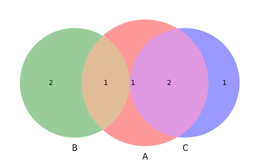

```python
import matplotlib.pyplot as plt
from matplotlib_venn import venn2

setA = set(['a1','a2','a3','a4'])
setB = set(['a1','a5','a6'])
setC = set(['a2','a3','a7'])
setS = set(['a1','a2','a3','a4','a5','a6','a7','a8','a9','a10'])


venn3([setA, setB, setC], ('A', 'B','C'))
plt.show()
```

a) $$P(A\cup B) = P(A)+P(B)-P(A\cap B)$$ $$P(A\cap B) = P(A)+P(B)-P(A\cup B) = 0,4+0,3-0,6 = 0,1$$

b) $$P(A\cup B\cup C) = P(A)+P(B)+P(C)-P(A\cap B)-P(A\cap C)-P(B\cap C)-P(A\cap B\cap C)$$ $$P(A\cap B\cap C) = P(A\cup B\cup C)- P(A)-P(B)-P(C)+P(A\cap B)+P(A\cap C)+P(B\cap C)$$ må løyse for $P(A\cap C)$ og $P(B\cap C)$ $$P(A\cap C) = P(A)+P(C) -P(A\cup C) = 0,2$$ $$P(B\cap C) = P(B)+P(C) -P(B\cup C) = 0$$ Siden $P(B\cap C)=Ø$ veit vi at også $P(A\cup B\cup C)$ må vere $Ø$, vi kan og sjå grafisk at det ikkje er noko felles snitt

c) $$P(A|B) = \frac{P(A\cap B)}{P(B)} = \frac{0,1}{0,3}= \frac{1}{3} $$

## Oppgave 5

I en befolkning er $8\%$ av mennene og $0.3\%$ av kvinnene fargeblinde. I en gruppe personer fra denne befolkningen er det dobbelt så mange kvinner som menn. En person som trekkes tilfeldig fra denne gruppen viser seg å være fargeblind.

- Hva er sannsynligheten for at denne personen er ei kvinne?

setter vi sammen får vi at $$P(K|F) = \frac{P(F|K)P(K)}{P(F)} = 0,0698$$

## Oppgave 6

La $X$ være en diskret fordelt stokastisk variabel med punktsannsynlighet $f(x)=P(X=x)$ som angitt i følgende tabell.

| $x$ |  | $f(x)$ |
| --- | --- | --- |
| $0$ |  | $0.05$ |
| $1$ |  | $0.10$ |
| $2$ |  | $0.25$ |
| $3$ |  | $0.40$ |
| $4$ |  | $0.15$ |
| $5$ |  | $0.05$ |

- Kjør python-koden under for å generere et stolpediagram for $f(x)$. *Merk: Studer hvilke funksjoner som benyttes slik at du kan skrive lignende kode selv senere.*

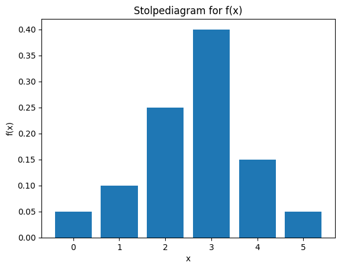

```python
#UTLEVERT KODE (ingenting her skal endres)

import numpy as np
import matplotlib.pyplot as plt

#utfallsrom
x=np.arange(6)
#punktsannsynlighet
f_x = np.array([0.05,0.10,0.25,0.40,0.15,0.05])
#stolpediagram
plt.bar(x, f_x)
plt.xlabel("x")
plt.ylabel("f(x)")
plt.title("Stolpediagram for f(x)")
plt.show()
```

- Bestem sannsynlighetene $P(X\leq 2)$, $P(X\leq 2|X<4)$ og $P(X\leq 2|X\geq 1)$.
- Finn kumulativ fordelingsfunksjon for $X$, $F(x)=P(X\leq x)$. (Husk at $F(x)$ er definert for alle $x\in\mathbb{R}$.)
- Kjør python-koden under for å generere et plott av $F(x)$. *Merk: Studer hvilke funksjoner som benyttes slik at du kan skrive lignende kode selv senere.*

$$ Besvarelse $$

1. $$ P(X \leq 2) = P(0) + P(1) + P(2) = 0.05 + 0.10 + 0.25 = 0.4 $$
2. $$ P(X \leq 2 | X < 4) = \frac{P(X \leq 2)}{P(X < 4)} = \frac{0.4}{0.8} = 0.5 $$
3. $$ P(X \leq 2 | X \geq 1) = \frac{0.10 + 0.25}{0.10 + 0.25 + 0.4 + 0.15 + 0.05} = \frac{7}{19} \approx 0.368 $$

$$ F(x) = \begin{cases} 0 & \text{for } x < 0 \\ 0.05 & \text{for } 0 \leq x < 1 \\ 0.15 & \text{for } 1 \leq x < 2 \\ 0.40 & \text{for } 2 \leq x < 3 \\ 0.80 & \text{for } 3 \leq x < 4 \\ 0.95 & \text{for } 4 \leq x < 5 \\ 1 & \text{for } x \geq 5 \end{cases} $$

```python
#UTLEVERT KODE (ingenting her skal endres)

import numpy as np
import matplotlib.pyplot as plt

# sett x-verdier og beregn tilhørende F(x)
x = [-1,0]
F_x = -[0,0] # start- og sluttverdi for x på intervallet [-1,0]

for i in range(5+1):    # for-løkke over verdiene 0,1,2,3,4,5
    x = x + [i,i+1]    #"+" legger her listene sammen til en lengre liste
    FF = np.sum(f_x[np.arange(i+1)])   # verdien til F(i)
    F_x = F_x + [FF,FF]

# lag plott av F(x)
plt.plot(x, F_x, color="red")
plt.xlabel("x")
plt.ylabel("F(x)")
plt.show()
```

[output not shown]

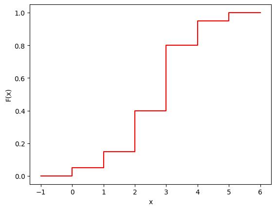

```python
import numpy as np
import matplotlib.pyplot as plt

# Initialiser x-verdier og F_x
x = [-1, 0]
F_x = [0, 0]  # F(x) er 0 for x < 0

# Sannsynligheter gitt i oppgaven
probabilities = [0.05, 0.10, 0.25, 0.40, 0.15, 0.05]

# Oppdater x og F_x basert på sannsynlighetene
for i, p in enumerate(probabilities):
    x += [i, i + 1]
    F_x += [F_x[-1] + p, F_x[-1] + p]

# Lag plott av F(x)
plt.plot(x, F_x, color="red")
plt.xlabel("x")
plt.ylabel("F(x)")
plt.show()
```

## Oppgave 7

La $X$ være en stokastisk variabel som beskriver hvor lang tid en komponent har fungert i det den svikter. Vi kaller da $X$ for *levetiden* for komponenten.

Levetiden $X$ (målt i antall år) til en bestemt type mekaniske komponenter har vist seg å følge en fordeling med kumulativ fordelingsfunksjon gitt ved \begin{align*} F_X(x) = 1 - \exp\left\{ -\frac{x^2}{\alpha}\right\}; x\geq 0, \end{align*} der $\alpha$ er en parameter som beskriver kvaliteten til komponentene.

### Deloppgave a)

Kjør python-koden under for å generere et plott av $F_X(x)$ når $\alpha=1$. *Merk: Studer koden slik at du kan skrive lignende kode selv senere.*

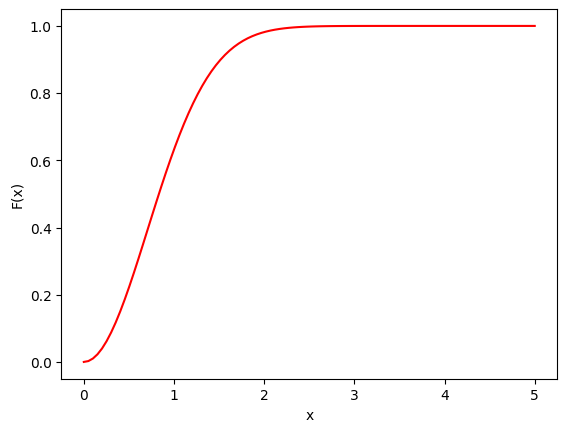

```python
#UTLEVERT KODE (ingenting her skal endres)

import numpy as np
import matplotlib.pyplot as plt

# Sett hvilke x-verdier du vil plotte for
x = np.linspace(0,5,100)

# Sett verdien for parameteren alpha
alpha = 1

# Beregn kumulativ fordelingsfunksjon
def F_X(x, alpha):
    return 1- np.exp(-x**2/alpha)

plt.plot(x, F_X(x, alpha), color="red")
plt.xlabel("x")
plt.ylabel("F(x)")
plt.show()
```

- Finn en formel for sannsynlighetstettheten $f_X(x)$ til $X$.
- Skriv python-kode som genererer et plott av $f_X(x)$ for $x\in (0,5)$. Skriv koden slik at du enkelt kan lage plott for ulike verdier av parameteren $\alpha$, tilsvarende som er gjort i koden over for å plotte $F_X(x)$.

$$ Besvarelse $$

Gitt den kumulative fordelingsfunksjonen $F_X(x)$ for ein stokastisk variabel $X$, kan vi finne sannsynlighetstetthetsfunksjonen $f_X(x)$ ved å derivere $F_X(x)$ med hensyn til $x$.

Den kumulative fordelingsfunksjonen er gitt ved:

$$ F_X(x) = 1 - \exp\left( -\frac{x^2}{\alpha} \right); \quad x \geq 0 $$

For å finne PDF $f_X(x)$, tar vi den deriverte av $F_X(x)$ med hensyn til $x$:

$$ f_X(x) = -\exp\left( -\frac{x^2}{\alpha} \right) \cdot \left( -\frac{2x}{\alpha} \right) = \frac{2x}{\alpha} \exp\left( -\frac{x^2}{\alpha} \right) $$

Så, sannsynlighetstetthetsfunksjonen $f_X(x)$ for $X$ er:

$$ f_X(x) = \frac{2x}{\alpha} \exp\left( -\frac{x^2}{\alpha} \right); \quad x \geq 0 $$

Dinna funksjonen beskrive sannsynlighetstettheta til levetiden $X$ for de mekaniske komponentane, gitt parametere $\alpha$ som beskrive kvaliteten på komponentane.

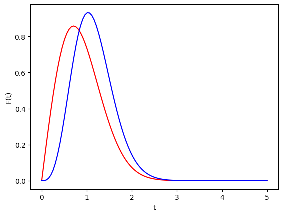

```python
import numpy as np
import matplotlib.pyplot as plt

x = np.linspace(0,5,100)

alpha = 1

def f_X(x, alpha):
    return (2*x)/alpha*np.exp(-x**2/alpha)
def f_Z(z, alpha):
    return 4*z/alpha*(1- np.exp(-z**2/alpha))*np.exp(-z**2/alpha)

plt.plot(x, f_X(x, alpha), color="red")
plt.plot(x, f_Z(x, alpha), color="blue")
plt.xlabel("t")
plt.ylabel("F(t)")
plt.show()
```

#### Her er deloppgave a slutt.

Et instrument inneholder to komponenter av denne typen, begge med samme kvalitetsparameter $\alpha$. De to komponentene svikter uavhengig av hverandre, og instrumentet fungerer så lenge minst en av de to komponentene fungerer. La $Z$ betegne levetiden til instrumentet.

### Deloppgave b)

- Finn en formel for sannsynligheten for at instrumentet fremdeles fungerer etter en tid $z$, dvs. $1-F_Z(z)=P(Z > z)$.
- Bestem sannsynlighetstettheten for $Z$, $f_Z(z)$.
- Der hvor du over skrev python-kode for å plotte $f_X(x)$, legg til python-kode for også å generere et plott av $f_Z(z)$. Inkluder plottet av $f_Z(z)$ i samme plott som $f_X(x)$, slik at du enkelt kan sammenligne de to sannsynlighetstetthetene. Kan du intuitivt forstå/forklare den kvalitative forskjellen mellom de to sannsynlighetstetthetene?

$$ Besvarelse $$

vi ser at med 2 komponenta som sliter uavhenging vil vi få ein større buffer for kor lenge systemet er holdbart, som stemmer med intusjonen. vi ser og at det blir meir normalfordelt

vi har at $X_1$ og $X_2$ er uavhengige, og $Z$ = $max(X_1,X_2)$. Vidare har vi då at $$ P(Z>z) = P(max(X_1,X_2)>z) $$

$$ P(Z>z) = 1 - P(X_1 \leq z)*P(X_2 \leq z) $$ Vi har eigenskapen at $P(X_1 \leq z)$ = $P(X_2 \leq z)$ = $F_x(z)$ $$ \Rightarrow P(Z>z) = 1 - [F_x(z)]^2 $$ omskriver at $1-F_Z(z)=P(Z > z)$

$$ F_Z(z) = 1 - (1 - [F_x(z)]^2) = [F_x(z)]^2 $$

finner $f_Z(z)$ ved å derivere $F_Z$

$$ f_Z(z) = \frac{d}{dz} [F_x(z)]^2 = 2F_x(z)*f_x(z) $$ som vi allereie har løyst $$ f_Z(z) = 2(1-exp(-\frac{z^2}{\alpha}))\frac{2z}{\alpha}exp(-\frac{z^2}{\alpha}) $$ som kan forenklast til, og gir $$ f_Z(z) = \frac{4z}{\alpha}(1-exp(\frac{-z^2}{\alpha}))exp(\frac{-z^2}{\alpha}); \quad z\geq 0 $$

## Oppgave 8

I et lotteri er det $300$ lodd. Tre av loddene gir en gevinst av type $A$ og tre andre lodd gir en gevinst av type $B$. De øvrige 294 loddene gir ingen gevinst. Ola kjøper fem lodd som han trekker tilfeldig blant de $300$ loddene. La $X$ betegne antall gevinster av type A som Ola vinner, og la $Y$ betegne antall gevinster han vinner av type B.

La $f_X(x)=P(X=x)$ betegne punktsannsynligheten for $X$, og la tilsvarende $f_Y(y)=P(Y=y)$ betegne punktsannsynligheten for $Y$. Simultan punktsannsynlighet for $X$ og $Y$ betegner vi med $f_{XY}(x,y)=P(X=x,Y=y)$.

- Benytt kombinatorikk-regler til å finne en formel for $f_X(x)$ som funksjon av $x=0,1,2,3$.
- Finn også en formel som gjelder for $f_{XY}(x,y)$ når $x,y\in\{0,1,2,3\}$, $x+y\leq 5$.

$$ Besvarelse $$

Vi har $300$ lodd der det er $3$ lodd av type $A$ og $3$ av tupe $B$. vi har at $f_X(x)=P(X=x)$ og antall måter å velge $A$ på er $3Cx$ resterande valg er då $297C(5-x)$ og måter å trekke 5 lodd er då $300C5$ $$ \Rightarrow f_X(x) = P(X=x) = \frac{\binom{3}{x} \binom{297}{5-x}}{\binom{300}{5}}

en formel som gjelder for $f_{XY}(x,y)$ når $x,y\in\{0,1,2,3\}$, $x+y\leq 5$. vi kan velge $A$ på $3Cx$ måter, $B$ på $3Cy$ måter og resten er då $294C(5-x-y)$ $$ \Rightarrow f_{XY}(x,y) = \frac{\binom{3}{x}\binom{3}{y}\binom{294}{5-x-y}}{\binom{300}{5}}

For å besvare neste spørsmål kan du benytte at vi generelt har sammenhengen \begin{align*} f_X(x) = \sum_y f_{XY}(x,y), \end{align*} der summen er over alle mulige verdier for $y$.

- Utled fra $f_{XY}(x,y)$ en formel for marginalfordelingen for $f_X(x)$ og observer at denne er identisk med formelen du fant over. *Hint: Du vil her få bruk for Vandermondes identitet, som sier at for alle ikke-negative heltall $r$, $m$ og $n$ har man at*

\begin{align*} \sum_{k=0}^r \binom{m}{k}\binom{n}{r-k} = \binom{m+n}{r}. \end{align*}

$$ Besvarelse $$

$$f_X(x) = \sum_y f_{XY}(x,y)$$ $y$ kan vere heiltall fra $0$ til $5-x$ $$\Rightarrow f(x) = \sum_{y=0}^{5-x}\frac{\binom{3}{x}\binom{3}{y}\binom{294}{5-x-y}}{\binom{300}{5}}$$ Så kan vi trekke ut det som ikkje påvirkast av summen $$f(x) = \frac{\binom{3}{x}\binom{3}{y}\binom{294}{5-x-y}}{\binom{300}{5}}\sum_{y=0}^{5-x}\binom{3}{y}\binom{294}{5-x-y}$$ Ved å ta i bruk Vandermondes teorem $$\sum_{k=0}^r \binom{m}{k}\binom{n}{r-k} = \binom{m+n}{r}.$$ der $m =3,n=294,k=y,r=(5-x)$ har vi at $$f(x) = \frac{\binom{3}{x} \binom{297}{5-x}}{\binom{300}{5}}$$

## Fasit:

- Oppgave 2: $0.0190, 1.30\cdot 10^{-6}$
- Oppgave 3: $0.0487, 0.0493, 0.0967$
- Oppgave 4: $0.1, 0, 1/3$
- Oppgave 5: $0.0698$
- Oppgave 6: $0.40, 0.5, 0.368$